# Analysis of expert grading

## Loading packages and reading data

```r
library(tidyverse)
library(xtable)
library(devtools)
```

q1 = “Does the plot clearly show the relationship?” Yes / No q2 = “Is the plot visually pleasing?” Yes / Somewhat / No q3 = “Can the plot be understood without a figure caption?” Yes / No q4 = “Are the legends and labels sufficient to explain what the plot is showing?” Yes / No q5 = “Are the plot text and labels large enough to read?” Yes / No q6 = “Do the plot text and labels use full words instead of abbreviations?” Yes / No

```r
grader1 <- read_csv("data/expert_grading/grader1_all.csv")
grader2 <- read_csv("data/expert_grading/grader2_all.csv")
grader3 <- read_csv("data/expert_grading/grader3_all.csv")
sumtable1 <- read_csv("data/base_table_all_FINAL.csv")
```

```r
sumtable2 <- read_csv("data/ggplot_table_all_FINAL.csv")
base_annots <- read_csv("data/base_annots_FINAL.csv", guess_max = 1e6)
ggplot_annots <- read_csv("data/ggplot_annots_FINAL.csv", guess_max = 1e6)
label_table <- function(tab) {
    tab %>%
        rename(
            prompt = peer_assignment_review_schema_part_prompt,
            option_text = peer_assignment_review_schema_part_option_text
        ) %>%
        mutate(
            question_num = case_when(
                str_detect(prompt, "clearly show") ~ "q1",
                str_detect(prompt, "visually pleasing") ~ "q2",
                str_detect(prompt, "without a figure caption") ~ "q3",
                str_detect(prompt, "legends and labels sufficient") ~ "q4",
                str_detect(prompt, "text and labels large enough") ~ "q5",
                str_detect(prompt, "full words") ~ "q6"
            )
        )
}

sumtable1 <- label_table(sumtable1)
sumtable2 <- label_table(sumtable2)
```

## Comparing grades among experts

For each plot, count the number of times that the *experts* answered “Yes” or “Somewhat” to the rubric question.

```r
identical(grader1$deid_url, grader2$deid_url)
```

```
## [1] TRUE
```

```r
identical(grader1$deid_url, grader3$deid_url)
```

```
## [1] TRUE
```

```r
all_graders <- rbind(grader1, grader2, grader3)

grading_summ <- all_graders %>%
    group_by(deid_url) %>%
    summarize(
        q1_y = sum(q1=="y"),
        q2_ys = sum(q2 %in% c("y", "s")),
        q3_y = sum(q3=="y"),
        q4_y = sum(q4=="y"),
        q5_y = sum(q5=="y"),
        q6_y = sum(q6=="y")
    )
```

For each rubric question, compute the percentage (out of all regraded plot submissions) of times that there was perfect agreeement.

```r
expert_num_agree <- rep(0,6)
for (i in 2:7) {
    cat("Rubric question", i-1, "\n")
    print(table(grading_summ[[i]]))
    num_perfect_agreement <- sum(grading_summ[[i]] %in% c(0,3))
    expert_num_agree[i-1] <- num_perfect_agreement
    cat(num_perfect_agreement, "/", nrow(grading_summ), "=", round(num_perfect_agreement/nrow(grading_summ), 3), "\n\n\n")
}
```

```
## Rubric question 1
##
##  0  1  2  3
##  9  9 42 60
## 69 / 120 = 0.575
##
##
## Rubric question 2
##
##  0  1  2  3
##  4 12 32 72
## 76 / 120 = 0.633
##
##
## Rubric question 3
##
##  0  1  2  3
##  6 20 64 30
## 36 / 120 = 0.3
##
##
## Rubric question 4
##
##  0  1  2  3
## 11 15 60 34
## 45 / 120 = 0.375
##
##
## Rubric question 5
##
##  0  1  2  3
##  4 13 18 85
## 89 / 120 = 0.742
##
##
## Rubric question 6
##
##  0  1  2  3
##  3 27 21 69
## 72 / 120 = 0.6
```

## Comparing expert grades to student grades

For each plot, compute the percentage of times that the *students* answered “Yes” or “Somewhat” to the rubric question.

```r
urls <- grader1$deid_url
student_reviews <- do.call(rbind, lapply(urls, function(url) {
    student_reviews <- rbind(sumtable1 %>% filter(deid_url==url), sumtable2 %>% filter(deid_url==url))
    sapply(1:6, function(j) {
        resps <- student_reviews %>%
            filter(question_num==paste0("q",j)) %>%
            pull(option_text)
        if (length(resps)==0) {
            NA
        } else {
            sum(resps %in% c("Yes", "Somewhat"))/length(resps)
            # paste(sum(resps %in% c("Yes", "Somewhat")), "/", length(resps))
        }
    })
}))
colnames(student_reviews) <- paste0("q", 1:6, "_stu")
```

Compare student percentages to expert percentages.

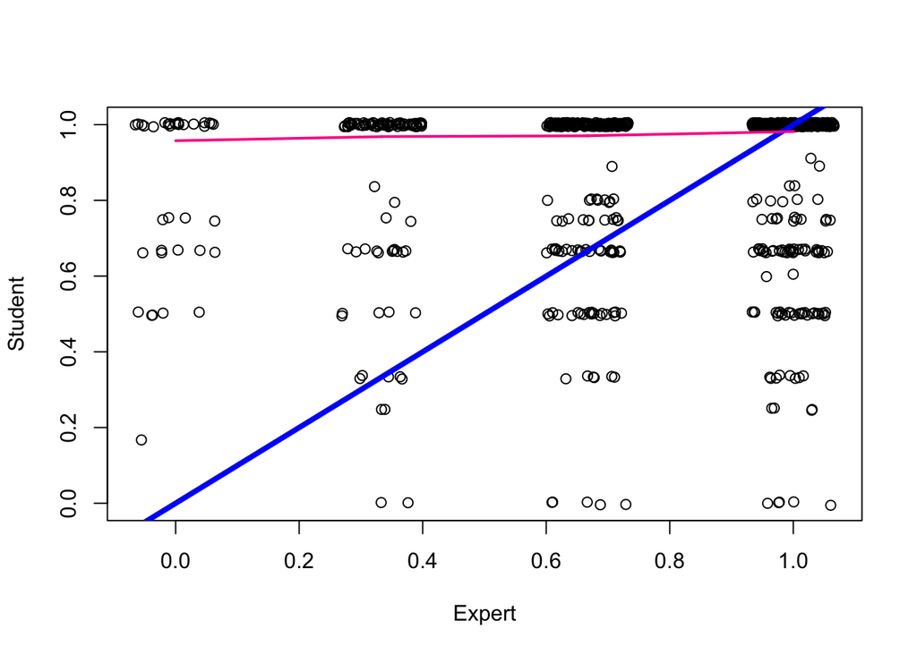

```r
combined_grading_summ <- as.matrix(cbind(grading_summ[,2:7]/3, student_reviews))
plot(jitter(x <- as.numeric(combined_grading_summ[,1:6])), jitter(y <- as.numeric(combined_grading_summ[,7:12])), xlab = "Expert", ylab = "Student")
abline(a = 0, b = 1, col = "blue", lwd = 4)
lines(lowess(x, y), lwd = 2, col = "deeppink")
```

Compute difference in percentages. Look at distribution and mean.

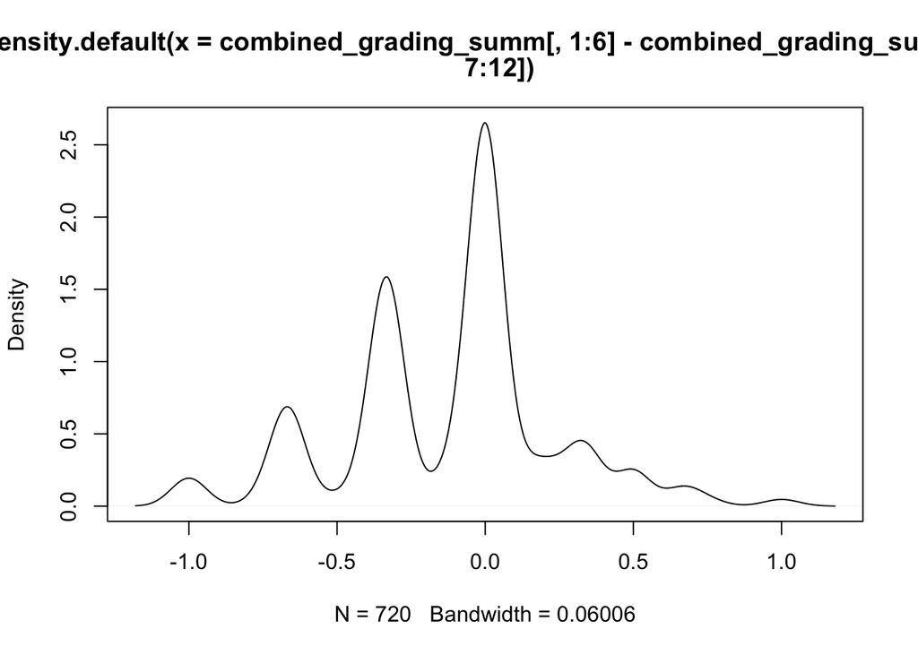

```r
plot(density(combined_grading_summ[,1:6]-combined_grading_summ[,7:12]))
```

```r
mean(combined_grading_summ[,1:6]-combined_grading_summ[,7:12])
```

```
## [1] -0.1180941
```

Categorize percentages as pos(itive), neg(ative), or split to assess agreement between students and experts as a whole.

```r
combined_grading_summ_cat <- matrix("split", nrow = nrow(combined_grading_summ), ncol = ncol(combined_grading_summ))
combined_grading_summ_cat[combined_grading_summ > 0.5] <- "pos"
combined_grading_summ_cat[combined_grading_summ < 0.5] <- "neg"
expert_student_match <- combined_grading_summ_cat[,1:6]==combined_grading_summ_cat[,7:12]
```

For most plots, students and experts agree on at least 5 of the 6 main rubric questions:

```r
table(rowSums(expert_student_match))
```

```
##
##  0  1  2  3  4  5  6
##  1  5  7 23 21 26 37
```

What are the rates of agreement for the different questions?

```r
colSums(expert_student_match)
```

```
## [1] 83 98 83 83 96 81
```

```r
colSums(expert_student_match)/120
```

```
## [1] 0.6916667 0.8166667 0.6916667 0.6916667 0.8000000 0.6750000
```

Patterns of agreement/disagreement:

```r
colnames(expert_student_match) <- paste0("q", 1:6, "_y")
expert_student_match_patterns <- as_tibble(expert_student_match) %>%
    count(q1_y, q2_y, q3_y, q4_y, q5_y, q6_y) %>%
    arrange(n)
expert_student_match_patterns %>% as.data.frame()
```

```
##     q1_y  q2_y  q3_y  q4_y  q5_y  q6_y  n
## 1  FALSE FALSE FALSE FALSE FALSE FALSE  1
## 2  FALSE FALSE FALSE FALSE FALSE  TRUE  1
## 3  FALSE FALSE FALSE FALSE  TRUE FALSE  1
## 4  FALSE FALSE FALSE  TRUE FALSE FALSE  1
## 5  FALSE FALSE  TRUE FALSE  TRUE FALSE  1
## 6  FALSE FALSE  TRUE  TRUE  TRUE  TRUE  1
## 7  FALSE  TRUE FALSE  TRUE FALSE  TRUE  1
## 8  FALSE  TRUE FALSE  TRUE  TRUE  TRUE  1
## 9  FALSE  TRUE  TRUE FALSE FALSE  TRUE  1
## 10 FALSE  TRUE  TRUE FALSE  TRUE FALSE  1
## 11  TRUE FALSE FALSE FALSE  TRUE FALSE  1
## 12  TRUE FALSE FALSE FALSE  TRUE  TRUE  1
## 13  TRUE FALSE FALSE  TRUE FALSE  TRUE  1
## 14  TRUE FALSE FALSE  TRUE  TRUE FALSE  1
```

[output cut: 27 more lines]

Combine expert-only and student-expert results into one table:

```r
summ_all <- read_csv("data/summ_all_FINAL.csv", guess_max = 1e6)
```

```r
prompts <- tibble(
    prompt = unique(summ_all$prompt),
    short_prompt = c(
        "Legends and labels sufficient?",
        "Text and labels large enough?",
        "Understandable without caption?",
        "Did they upload a plot?",
        "Use full words vs. abbreviations?",
        "Clearly shows relationships?",
        "Is the plot visually pleasing?",
        "Clearly shows relationship?"
    )
)

student_expert_num_agree <- colSums(expert_student_match)

percentage_string <- function(num, total) {
    perc <- paste0(round(num/total, 3)*100, "%")
    paste0(perc, " (", num, "/", total, ")")
}

df_agreement <- data.frame(
    prompt = c("Clearly shows relationship?", "Is the plot visually pleasing?", "Understandable without caption?", "Legends and labels sufficient?", "Text and labels large enough?", "Use full words vs. abbreviations?"),
    expert = percentage_string(expert_num_agree, 120),
    student_expert = percentage_string(student_expert_num_agree, 120)
)
colnames(df_agreement) <- c("Prompt", "Among experts", "Between students and experts")
print(xtable(df_agreement), include.rownames = FALSE)
```

```
## % latex table generated in R 3.5.2 by xtable 1.8-4 package
## % Thu Jul 11 14:38:27 2019
## \begin{table}[ht]
## \centering
## \begin{tabular}{lll}
##   \hline
## Prompt & Among experts & Between students and experts \\
##   \hline
## Clearly shows relationship? & 57.5\% (69/120) & 69.2\% (83/120) \\
##   Is the plot visually pleasing? & 63.3\% (76/120) & 81.7\% (98/120) \\
##   Understandable without caption? & 30\% (36/120) & 69.2\% (83/120) \\
##   Legends and labels sufficient? & 37.5\% (45/120) & 69.2\% (83/120) \\
##   Text and labels large enough? & 74.2\% (89/120) & 80\% (96/120) \\
##   Use full words vs. abbreviations? & 60\% (72/120) & 67.5\% (81/120) \\
##    \hline
## \end{tabular}
## \end{table}
```

Metadata for sampled plots

```r
graded_plot_metadata <- tibble(deid_url = urls)
graded_plot_metadata <- graded_plot_metadata %>%
    left_join(
        unique(rbind(
            base_annots %>% select(deid_url, section, correct_system, num_panels, other_visual_grouping) %>% mutate(arm = "base"),
            ggplot_annots %>% select(deid_url, section, correct_system, num_panels, other_visual_grouping) %>% mutate(arm = "ggplot")
        ))
    )
graded_plot_metadata %>% count(arm, section)
```

```
## # A tibble: 4 x 3
##   arm    section     n
##   <chr>  <chr>   <int>
## 1 base   complex    40
## 2 base   simple     20
## 3 ggplot complex    40
## 4 ggplot simple     20
```